# IODS course project

Juuso Repo

# About the project

I feel quite *excited* about the course. I am new to R, Github, and a lot of other stuff in the course. Will definitely learn a lot!

See my course repo at: https://github.com/juusorepo/IODS-project

# 2 Linear Regression

*Description of the work for this week*

The data is based on an International survey of Approaches to Learning. It was gathered in 2014-2015 in Finland by Kimmo Vehkalahti I have prepared a subdataset to for this analysis. It consists of **166 respondent and 7 variables.** Background variables include age and gender of the students. Measures include Points (overall), Attitude (towards statistics) and three measures of learning styles: Deep, Strategic and Surface. [see more](https://www.mv.helsinki.fi/home/kvehkala/JYTmooc/JYTOPKYS2-meta.txt)

## 1. Read data

```r
# Read data
library(dplyr)
lr14 <- read.csv("learning2014.csv")
lr14 <- select(lr14, -1)
head(lr14)
```

```
##   gender Age Attitude Points  stra     surf     deep
## 1      F  53       37     25 3.375 2.583333 3.583333
## 2      M  55       31     12 2.750 3.166667 2.916667
## 3      F  49       25     24 3.625 2.250000 3.500000
## 4      M  53       35     10 3.125 2.250000 3.500000
## 5      M  49       37     22 3.625 2.833333 3.666667
## 6      F  38       38     21 3.625 2.416667 4.750000
```

```r
str(lr14)
```

```
## 'data.frame':    166 obs. of  7 variables:
##  $ gender  : Factor w/ 2 levels "F","M": 1 2 1 2 2 1 2 1 2 1 ...
##  $ Age     : int  53 55 49 53 49 38 50 37 37 42 ...
##  $ Attitude: int  37 31 25 35 37 38 35 29 38 21 ...
##  $ Points  : int  25 12 24 10 22 21 21 31 24 26 ...
##  $ stra    : num  3.38 2.75 3.62 3.12 3.62 ...
##  $ surf    : num  2.58 3.17 2.25 2.25 2.83 ...
##  $ deep    : num  3.58 2.92 3.5 3.5 3.67 ...
```

```r
dim(lr14)
```

```
## [1] 166   7
```

## 2 Explore the data

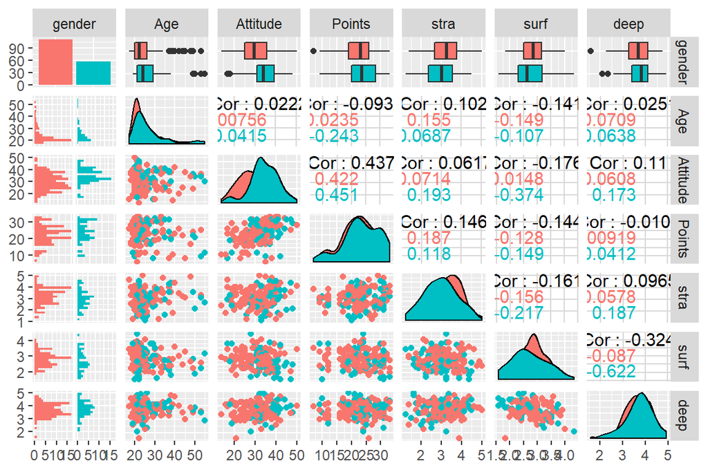

```r
# EDA
library(ggplot2)
library(GGally)
# ggpairs for good overview
p3 = ggpairs(lr14, aes(col=gender), lower = list(combo = wrap("facethist", bins = 20)))
p3
```

**Some observations:**

- The majority of respondents are females (red color) and under 30-year-olds (bar chart).
- The variance of Points is greater among women, although the mean is quite the same (boxplot).
- The highest correlations are between Attitude and Points (0.437) & surf and deep (-0.324) (correlations).

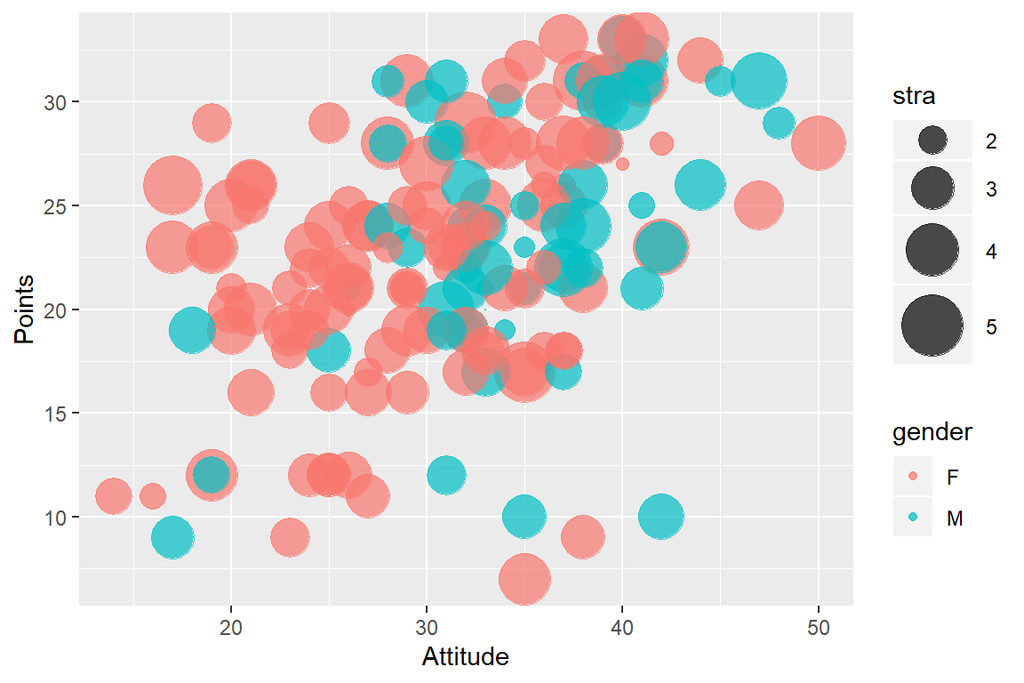

```r
# Bubble chart
p4 = ggplot(lr14, aes(x=Attitude, y=Points, size=stra, col=gender)) + geom_point(alpha=0.7) + scale_size(range = c(.1, 12), name="stra")
p4
```

## 3 Linear regression

The dependent variable was Points. In the first model, the explanatory variables were Attitude, stra and deep. According to the results, only Attitude had significant relationship with the target variable. Thus, I made a new, simple linear regression model with only Attitude as an explanatory variable. The summaries of both models below.

**Interpretation of the statistical test:**

- p-value for the model is less than .001 so the model is statistically significant.
- p-value for Attitude is less than .001 so its relationship with the target variable is statistically significant.

```r
model_1 <- lm(Points ~ Attitude + stra + deep, data = lr14)
summary(model_1)
```

```
##
## Call:
## lm(formula = Points ~ Attitude + stra + deep, data = lr14)
##
## Residuals:
##      Min       1Q   Median       3Q      Max
## -17.5239  -3.4276   0.5474   3.8220  11.5112
##
## Coefficients:
##             Estimate Std. Error t value Pr(>|t|)
## (Intercept) 11.39145    3.40775   3.343  0.00103 **
## Attitude     0.35254    0.05683   6.203 4.44e-09 ***
## stra         0.96208    0.53668   1.793  0.07489 .
## deep        -0.74920    0.75066  -0.998  0.31974
## ---
## Signif. codes:  0 '***' 0.001 '**' 0.01 '*' 0.05 '.' 0.1 ' ' 1
##
## Residual standard error: 5.289 on 162 degrees of freedom
## Multiple R-squared:  0.2097, Adjusted R-squared:  0.195
## F-statistic: 14.33 on 3 and 162 DF,  p-value: 2.521e-08
```

```r
model_2 <- lm(Points ~ Attitude, data = lr14)
summary(model_2)
```

```
##
## Call:
## lm(formula = Points ~ Attitude, data = lr14)
##
## Residuals:
##      Min       1Q   Median       3Q      Max
## -16.9763  -3.2119   0.4339   4.1534  10.6645
##
## Coefficients:
##             Estimate Std. Error t value Pr(>|t|)
## (Intercept) 11.63715    1.83035   6.358 1.95e-09 ***
## Attitude     0.35255    0.05674   6.214 4.12e-09 ***
## ---
## Signif. codes:  0 '***' 0.001 '**' 0.01 '*' 0.05 '.' 0.1 ' ' 1
##
## Residual standard error: 5.32 on 164 degrees of freedom
## Multiple R-squared:  0.1906, Adjusted R-squared:  0.1856
## F-statistic: 38.61 on 1 and 164 DF,  p-value: 4.119e-09
```

## 4 Model interpretation

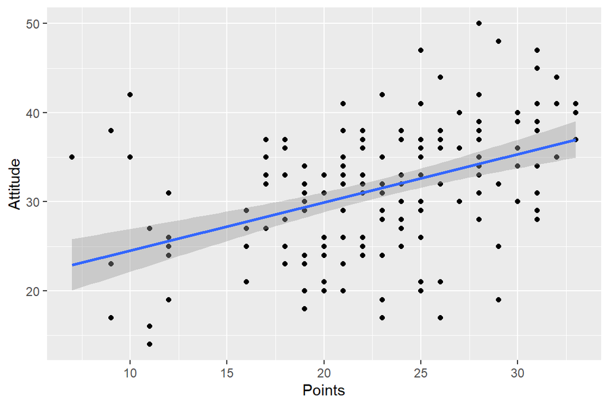

```r
qplot(Points, Attitude, data = lr14) + geom_smooth(method = "lm")
```